# Credit Card Clients Analysis(Decision Tree)

This command is used to view the Original DataSet

```r
View(default_of_credit_card_clients)
```

The orginal dataset is being duplicated into another document before further analysis.

```r
credit_clients2=default_of_credit_card_clients
```

The Structure of the duplicated Dataset is Viewed using this function

```r
str(credit_clients2)
```

```
Classes ‘tbl_df’, ‘tbl’ and 'data.frame':   30000 obs. of  25 variables:
 $ ID       : num  1 2 3 4 5 6 7 8 9 10 ...
 $ LIMIT_BAL: num  20000 120000 90000 50000 50000 50000 500000 100000 140000 20000 ...
 $ SEX      : num  2 2 2 2 1 1 1 2 2 1 ...
 $ EDUCATION: num  2 2 2 2 2 1 1 2 3 3 ...
 $ MARRIAGE : num  1 2 2 1 1 2 2 2 1 2 ...
 $ AGE      : num  24 26 34 37 57 37 29 23 28 35 ...
 $ PAY_0    : num  2 -1 0 0 -1 0 0 0 0 -2 ...
 $ PAY_2    : num  2 2 0 0 0 0 0 -1 0 -2 ...
 $ PAY_3    : num  -1 0 0 0 -1 0 0 -1 2 -2 ...
 $ PAY_4    : num  -1 0 0 0 0 0 0 0 0 -2 ...
 $ PAY_5    : num  -2 0 0 0 0 0 0 0 0 -1 ...
 $ PAY_6    : num  -2 2 0 0 0 0 0 -1 0 -1 ...
 $ BILL_AMT1: num  3913 2682 29239 46990 8617 ...
 $ BILL_AMT2: num  3102 1725 14027 48233 5670 ...
 $ BILL_AMT3: num  689 2682 13559 49291 35835 ...
 $ BILL_AMT4: num  0 3272 14331 28314 20940 ...
 $ BILL_AMT5: num  0 3455 14948 28959 19146 ...
 $ BILL_AMT6: num  0 3261 15549 29547 19131 ...
 $ PAY_AMT1 : num  0 0 1518 2000 2000 ...
 $ PAY_AMT2 : num  689 1000 1500 2019 36681 ...
 $ PAY_AMT3 : num  0 1000 1000 1200 10000 657 38000 0 432 0 ...
 $ PAY_AMT4 : num  0 1000 1000 1100 9000 ...
 $ PAY_AMT5 : num  0 0 1000 1069 689 ...
 $ PAY_AMT6 : num  0 2000 5000 1000 679 ...
 $ dpnm     : num  1 1 0 0 0 0 0 0 0 0 ...
```

The Summary of the Dataset is derived using this function

```r
summary(credit_clients2)
```

```
       ID          LIMIT_BAL            SEX          EDUCATION        MARRIAGE
 Min.   :    1   Min.   :  10000   Min.   :1.000   Min.   :0.000   Min.   :0.000
 1st Qu.: 7501   1st Qu.:  50000   1st Qu.:1.000   1st Qu.:1.000   1st Qu.:1.000
 Median :15000   Median : 140000   Median :2.000   Median :2.000   Median :2.000
 Mean   :15000   Mean   : 167484   Mean   :1.604   Mean   :1.853   Mean   :1.552
 3rd Qu.:22500   3rd Qu.: 240000   3rd Qu.:2.000   3rd Qu.:2.000   3rd Qu.:2.000
 Max.   :30000   Max.   :1000000   Max.   :2.000   Max.   :6.000   Max.   :3.000
      AGE            PAY_0             PAY_2             PAY_3             PAY_4
 Min.   :21.00   Min.   :-2.0000   Min.   :-2.0000   Min.   :-2.0000   Min.   :-2.0000
 1st Qu.:28.00   1st Qu.:-1.0000   1st Qu.:-1.0000   1st Qu.:-1.0000   1st Qu.:-1.0000
 Median :34.00   Median : 0.0000   Median : 0.0000   Median : 0.0000   Median : 0.0000
 Mean   :35.49   Mean   :-0.0167   Mean   :-0.1338   Mean   :-0.1662   Mean   :-0.2207
 3rd Qu.:41.00   3rd Qu.: 0.0000   3rd Qu.: 0.0000   3rd Qu.: 0.0000   3rd Qu.: 0.0000
 Max.   :79.00   Max.   : 8.0000   Max.   : 8.0000   Max.   : 8.0000   Max.   : 8.0000
     PAY_5             PAY_6           BILL_AMT1         BILL_AMT2        BILL_AMT3
 Min.   :-2.0000   Min.   :-2.0000   Min.   :-165580   Min.   :-69777   Min.   :-157264
 1st Qu.:-1.0000   1st Qu.:-1.0000   1st Qu.:   3559   1st Qu.:  2985   1st Qu.:   2666
 Median : 0.0000   Median : 0.0000   Median :  22382   Median : 21200   Median :  20088
 Mean   :-0.2662   Mean   :-0.2911   Mean   :  51223   Mean   : 49179   Mean   :  47013
 3rd Qu.: 0.0000   3rd Qu.: 0.0000   3rd Qu.:  67091   3rd Qu.: 64006   3rd Qu.:  60165
 Max.   : 8.0000   Max.   : 8.0000   Max.   : 964511   Max.   :983931   Max.   :1664089
   BILL_AMT4         BILL_AMT5        BILL_AMT6          PAY_AMT1         PAY_AMT2
 Min.   :-170000   Min.   :-81334   Min.   :-339603   Min.   :     0   Min.   :      0
 1st Qu.:   2327   1st Qu.:  1763   1st Qu.:   1256   1st Qu.:  1000   1st Qu.:    833
 Median :  19052   Median : 18104   Median :  17071   Median :  2100   Median :   2009
 Mean   :  43263   Mean   : 40311   Mean   :  38872   Mean   :  5664   Mean   :   5921
 3rd Qu.:  54506   3rd Qu.: 50190   3rd Qu.:  49198   3rd Qu.:  5006   3rd Qu.:   5000
 Max.   : 891586   Max.   :927171   Max.   : 961664   Max.   :873552   Max.   :1684259
    PAY_AMT3         PAY_AMT4         PAY_AMT5           PAY_AMT6             dpnm
 Min.   :     0   Min.   :     0   Min.   :     0.0   Min.   :     0.0   Min.   :0.0000
 1st Qu.:   390   1st Qu.:   296   1st Qu.:   252.5   1st Qu.:   117.8   1st Qu.:0.0000
 Median :  1800   Median :  1500   Median :  1500.0   Median :  1500.0   Median :0.0000
 Mean   :  5226   Mean   :  4826   Mean   :  4799.4   Mean   :  5215.5   Mean   :0.2212
 3rd Qu.:  4505   3rd Qu.:  4013   3rd Qu.:  4031.5   3rd Qu.:  4000.0   3rd Qu.:0.0000
 Max.   :896040   Max.   :621000   Max.   :426529.0   Max.   :528666.0   Max.   :1.0000
```

Using caTools Library, we factorize the dependent variable(dpnm) and education,SampleSplit(sample_cc)with a Ratio(0.8),Train(train_cc)and Test(test_cc) the Dataset.

```r
library(caTools)
credit_clients2$dpnm=factor(credit_clients2$dpnm,levels = c(0,1))
credit_clients2$EDUCATION=factor(credit_clients2$EDUCATION,levels = c(1,2,3,4,5,6))
sample_cc=sample.split(credit_clients2,SplitRatio = 0.8)
sample_cc
```

```
 [1]  TRUE  TRUE  TRUE  TRUE  TRUE  TRUE  TRUE FALSE  TRUE  TRUE  TRUE  TRUE  TRUE  TRUE
[15]  TRUE  TRUE FALSE  TRUE  TRUE FALSE FALSE  TRUE  TRUE  TRUE FALSE
```

```r
train_cc=subset(credit_clients2,sample_cc=="TRUE")
```

```
Length of logical index must be 1 or 30000, not 25
```

```r
train_cc
```

| ID | LIMIT_BAL | SEX | EDUCATION | MARRIAGE | AGE | PAY_0 | PAY_2 | PAY_3 | PAY_4 | PAY_5 | PAY_6 | BILL_AMT1 | BILL_AMT2 | BILL_AMT3 | BILL_AMT4 | BILL_AMT5 | BILL_AMT6 | PAY_AMT1 | PAY_AMT2 | PAY_AMT3 | PAY_AMT4 | PAY_AMT5 | PAY_AMT6 | dpnm |
| --- | --- | --- | --- | --- | --- | --- | --- | --- | --- | --- | --- | --- | --- | --- | --- | --- | --- | --- | --- | --- | --- | --- | --- | --- |
| 1 | 20000 | 2 | 2 | 1 | 24 | 2 | 2 | -1 | -1 | -2 | -2 | 3913 | 3102 | 689 | 0 | 0 | 0 | 0 | 689 | 0 | 0 | 0 | 0 | 1 |
| 2 | 120000 | 2 | 2 | 2 | 26 | -1 | 2 | 0 | 0 | 0 | 2 | 2682 | 1725 | 2682 | 3272 | 3455 | 3261 | 0 | 1000 | 1000 | 1000 | 0 | 2000 | 1 |
| 3 | 90000 | 2 | 2 | 2 | 34 | 0 | 0 | 0 | 0 | 0 | 0 | 29239 | 14027 | 13559 | 14331 | 14948 | 15549 | 1518 | 1500 | 1000 | 1000 | 1000 | 5000 | 0 |
| 4 | 50000 | 2 | 2 | 1 | 37 | 0 | 0 | 0 | 0 | 0 | 0 | 46990 | 48233 | 49291 | 28314 | 28959 | 29547 | 2000 | 2019 | 1200 | 1100 | 1069 | 1000 | 0 |
| 5 | 50000 | 1 | 2 | 1 | 57 | -1 | 0 | -1 | 0 | 0 | 0 | 8617 | 5670 | 35835 | 20940 | 19146 | 19131 | 2000 | 36681 | 10000 | 9000 | 689 | 679 | 0 |
| 6 | 50000 | 1 | 1 | 2 | 37 | 0 | 0 | 0 | 0 | 0 | 0 | 64400 | 57069 | 57608 | 19394 | 19619 | 20024 | 2500 | 1815 | 657 | 1000 | 1000 | 800 | 0 |
| 7 | 500000 | 1 | 1 | 2 | 29 | 0 | 0 | 0 | 0 | 0 | 0 | 367965 | 412023 | 445007 | 542653 | 483003 | 473944 | 55000 | 40000 | 38000 | 20239 | 13750 | 13770 | 0 |
| 9 | 140000 | 2 | 3 | 1 | 28 | 0 | 0 | 2 | 0 | 0 | 0 | 11285 | 14096 | 12108 | 12211 | 11793 | 3719 | 3329 | 0 | 432 | 1000 | 1000 | 1000 | 0 |
| 10 | 20000 | 1 | 3 | 2 | 35 | -2 | -2 | -2 | -2 | -1 | -1 | 0 | 0 | 0 | 0 | 13007 | 13912 | 0 | 0 | 0 | 13007 | 1122 | 0 | 0 |
| 11 | 200000 | 2 | 3 | 2 | 34 | 0 | 0 | 2 | 0 | 0 | -1 | 11073 | 9787 | 5535 | 2513 | 1828 | 3731 | 2306 | 12 | 50 | 300 | 3738 | 66 | 0 |

[output cut: 990 more lines]

```r
test_cc=subset(credit_clients2,sample_cc=="FALSE")
```

```
Length of logical index must be 1 or 30000, not 25
```

```r
test_cc
```

| ID | LIMIT_BAL | SEX | EDUCATION | MARRIAGE | AGE | PAY_0 | PAY_2 | PAY_3 | PAY_4 | PAY_5 | PAY_6 | BILL_AMT1 | BILL_AMT2 | BILL_AMT3 | BILL_AMT4 | BILL_AMT5 | BILL_AMT6 | PAY_AMT1 | PAY_AMT2 | PAY_AMT3 | PAY_AMT4 | PAY_AMT5 | PAY_AMT6 | dpnm |
| --- | --- | --- | --- | --- | --- | --- | --- | --- | --- | --- | --- | --- | --- | --- | --- | --- | --- | --- | --- | --- | --- | --- | --- | --- |
| 8 | 100000 | 2 | 2 | 2 | 23 | 0 | -1 | -1 | 0 | 0 | -1 | 11876 | 380 | 601 | 221 | -159 | 567 | 380 | 601 | 0 | 581 | 1687 | 1542 | 0 |
| 17 | 20000 | 1 | 1 | 2 | 24 | 0 | 0 | 2 | 2 | 2 | 2 | 15376 | 18010 | 17428 | 18338 | 17905 | 19104 | 3200 | 0 | 1500 | 0 | 1650 | 0 | 1 |
| 20 | 180000 | 2 | 1 | 2 | 29 | 1 | -2 | -2 | -2 | -2 | -2 | 0 | 0 | 0 | 0 | 0 | 0 | 0 | 0 | 0 | 0 | 0 | 0 | 0 |
| 21 | 130000 | 2 | 3 | 2 | 39 | 0 | 0 | 0 | 0 | 0 | -1 | 38358 | 27688 | 24489 | 20616 | 11802 | 930 | 3000 | 1537 | 1000 | 2000 | 930 | 33764 | 0 |
| 25 | 90000 | 1 | 1 | 2 | 23 | 0 | 0 | 0 | -1 | 0 | 0 | 4744 | 7070 | 0 | 5398 | 6360 | 8292 | 5757 | 0 | 5398 | 1200 | 2045 | 2000 | 0 |
| 33 | 100000 | 1 | 1 | 2 | 32 | 0 | 0 | 0 | 0 | 0 | 0 | 93036 | 84071 | 82880 | 80958 | 78703 | 75589 | 3023 | 3511 | 3302 | 3204 | 3200 | 2504 | 0 |
| 42 | 70000 | 2 | 1 | 2 | 25 | 0 | 0 | 0 | 0 | 0 | 0 | 67521 | 66999 | 63949 | 63699 | 64718 | 65970 | 3000 | 4500 | 4042 | 2500 | 2800 | 2500 | 0 |
| 45 | 40000 | 2 | 1 | 2 | 30 | 0 | 0 | 0 | 2 | 0 | 0 | 18927 | 21295 | 25921 | 25209 | 26636 | 29197 | 3000 | 5000 | 0 | 2000 | 3000 | 0 | 0 |
| 46 | 210000 | 1 | 1 | 2 | 29 | -2 | -2 | -2 | -2 | -2 | -2 | 0 | 0 | 0 | 0 | 0 | 0 | 0 | 0 | 0 | 0 | 0 | 0 | 1 |
| 50 | 20000 | 1 | 1 | 2 | 24 | 0 | 0 | 0 | 0 | 0 | 0 | 17447 | 18479 | 19476 | 19865 | 20480 | 20063 | 1318 | 1315 | 704 | 928 | 912 | 1069 | 0 |

[output cut: 990 more lines]

Post the Train and Test Process of the dataset,we use (rpart) and (rpart.plot) library to derive the decision tree for the test data that is assigned. We use rpart.control function to control the Decision Tree limits. We use Printcp,Plotcp function to rectify if there were any overfit in the derived decision tree.

```r
library(rpart)
library(rpart.plot)
my_cc_model1=rpart.control(minsplit = 6,minbucket = round(5/3),maxdepth = 6,cp = 0)
my_cc_model=rpart(dpnm~.,data = test_cc,method = "class",
                  control =my_cc_model1)
my_cc_model
```

```
n= 6000

node), split, n, loss, yval, (yprob)
      * denotes terminal node

  1) root 6000 1337 0 (0.77716667 0.22283333)
    2) PAY_0< 1.5 5356  884 0 (0.83495146 0.16504854)
      4) PAY_2< 1.5 4942  715 0 (0.85532173 0.14467827)
        8) PAY_AMT2>=1500.5 3112  328 0 (0.89460154 0.10539846)
         16) PAY_5< 1 2988  295 0 (0.90127175 0.09872825)
           32) BILL_AMT3< 477175.5 2983  291 0 (0.90244720 0.09755280) *
           33) BILL_AMT3>=477175.5 5    1 1 (0.20000000 0.80000000) *
         17) PAY_5>=1 124   33 0 (0.73387097 0.26612903)
           34) PAY_AMT3>=3.5 101   21 0 (0.79207921 0.20792079) *
           35) PAY_AMT3< 3.5 23   11 1 (0.47826087 0.52173913)
             70) BILL_AMT1>=4100.5 17    6 0 (0.64705882 0.35294118) *
             71) BILL_AMT1< 4100.5 6    0 1 (0.00000000 1.00000000) *
        9) PAY_AMT2< 1500.5 1830  387 0 (0.78852459 0.21147541)
         18) PAY_AMT4>=0.5 1091  189 0 (0.82676444 0.17323556)
           36) BILL_AMT3< 342.5 282   27 0 (0.90425532 0.09574468)
             72) BILL_AMT1< 337307.5 280   25 0 (0.91071429 0.08928571) *
             73) BILL_AMT1>=337307.5 2    0 1 (0.00000000 1.00000000) *
           37) BILL_AMT3>=342.5 809  162 0 (0.79975278 0.20024722) *
         19) PAY_AMT4< 0.5 739  198 0 (0.73207037 0.26792963)
           38) BILL_AMT1>=2252 294   54 0 (0.81632653 0.18367347)
             76) BILL_AMT5< 40756.5 290   51 0 (0.82413793 0.17586207) *
             77) BILL_AMT5>=40756.5 4    1 1 (0.25000000 0.75000000) *
           39) BILL_AMT1< 2252 445  144 0 (0.67640449 0.32359551) *
      5) PAY_2>=1.5 414  169 0 (0.59178744 0.40821256)
       10) PAY_5< 1 298  105 0 (0.64765101 0.35234899)
         20) PAY_AMT6>=1581.5 91   19 0 (0.79120879 0.20879121)
           40) ID>=327 89   17 0 (0.80898876 0.19101124)
             80) ID< 27914.5 82   13 0 (0.84146341 0.15853659) *
             81) ID>=27914.5 7    3 1 (0.42857143 0.57142857) *
           41) ID< 327 2    0 1 (0.00000000 1.00000000) *
         21) PAY_AMT6< 1581.5 207   86 0 (0.58454106 0.41545894)
           42) PAY_6< -0.5 57   15 0 (0.73684211 0.26315789) *
           43) PAY_6>=-0.5 150   71 0 (0.52666667 0.47333333)
             86) BILL_AMT1>=18865 80   29 0 (0.63750000 0.36250000) *
             87) BILL_AMT1< 18865 70   28 1 (0.40000000 0.60000000) *
```

[output cut: 27 more lines]

```
            115) AGE< 60.5 159   61 1 (0.38364780 0.61635220) *
         29) BILL_AMT5>=30470.5 292   73 1 (0.25000000 0.75000000)
           58) PAY_AMT2>=15030.5 7    2 0 (0.71428571 0.28571429) *
           59) PAY_AMT2< 15030.5 285   68 1 (0.23859649 0.76140351) *
       15) BILL_AMT1< 18236 144   26 1 (0.18055556 0.81944444)
         30) AGE< 41.5 100   24 1 (0.24000000 0.76000000)
           60) PAY_AMT4>=2500 9    4 0 (0.55555556 0.44444444)
            120) BILL_AMT5< 18383.5 6    1 0 (0.83333333 0.16666667) *
            121) BILL_AMT5>=18383.5 3    0 1 (0.00000000 1.00000000) *
           61) PAY_AMT4< 2500 91   19 1 (0.20879121 0.79120879) *
         31) AGE>=41.5 44    2 1 (0.04545455 0.95454545)
           62) PAY_3< 1 10    2 1 (0.20000000 0.80000000)
            124) BILL_AMT4< 8682.5 2    0 0 (1.00000000 0.00000000) *
            125) BILL_AMT4>=8682.5 8    0 1 (0.00000000 1.00000000) *
           63) PAY_3>=1 34    0 1 (0.00000000 1.00000000) *
```

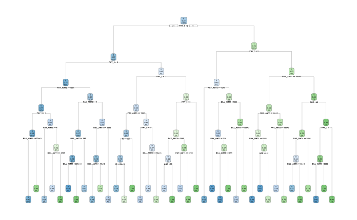

```r
rpart.plot(my_cc_model)
```

```r
printcp(my_cc_model)
```

```
Classification tree:
rpart(formula = dpnm ~ ., data = test_cc, method = "class", control = my_cc_model1)

Variables actually used in tree construction:
 [1] AGE       BILL_AMT1 BILL_AMT3 BILL_AMT4 BILL_AMT5 BILL_AMT6 ID        PAY_0
 [9] PAY_2     PAY_3     PAY_5     PAY_6     PAY_AMT1  PAY_AMT2  PAY_AMT3  PAY_AMT4
[17] PAY_AMT5  PAY_AMT6

Root node error: 1337/6000 = 0.22283

n= 6000

           CP nsplit rel error  xerror     xstd
1  0.19596111      0   1.00000 1.00000 0.024110
2  0.00448766      1   0.80404 0.80404 0.022218
3  0.00349040      3   0.79506 0.81825 0.022370
4  0.00336574      6   0.78459 0.81750 0.022362
5  0.00299177     11   0.76739 0.81301 0.022314
6  0.00224383     12   0.76440 0.81376 0.022322
7  0.00149589     13   0.76215 0.83022 0.022496
8  0.00134630     21   0.74869 0.83096 0.022504
9  0.00099726     26   0.74196 0.83096 0.022504
10 0.00074794     29   0.73897 0.83396 0.022535
11 0.00059835     33   0.73598 0.83844 0.022582
12 0.00000000     38   0.73298 0.83994 0.022597
```

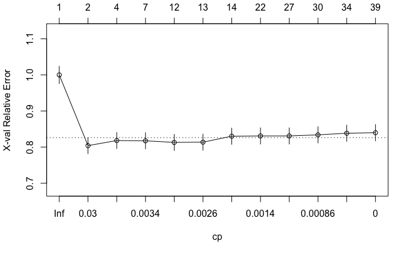

```r
plotcp(my_cc_model)
```

After deriving the Decision Tree,We Predict The Values of Test data. Then,we use table function to derive the Actual Value of the Dependent Variable(dpnm) from the dataset and the Predicted value of the using the test dataset.

```r
pred=predict(my_cc_model,test_cc,type = "class")
pred
```

```
   1    2    3    4    5    6    7    8    9   10   11   12   13   14   15   16   17   18
   0    0    0    0    0    0    0    0    0    0    0    1    1    0    0    0    0    0
  19   20   21   22   23   24   25   26   27   28   29   30   31   32   33   34   35   36
   0    0    0    0    0    1    0    0    0    0    0    0    0    0    0    0    0    0
  37   38   39   40   41   42   43   44   45   46   47   48   49   50   51   52   53   54
   1    0    0    0    0    0    0    1    1    0    0    0    0    0    0    0    1    0
  55   56   57   58   59   60   61   62   63   64   65   66   67   68   69   70   71   72
   0    0    0    0    0    0    0    0    0    1    0    0    0    0    0    0    0    0
  73   74   75   76   77   78   79   80   81   82   83   84   85   86   87   88   89   90
   1    0    0    0    0    0    0    1    0    0    0    1    0    0    0    0    0    0
  91   92   93   94   95   96   97   98   99  100  101  102  103  104  105  106  107  108
   0    0    0    0    0    0    1    0    0    0    0    0    0    0    0    0    0    0
 109  110  111  112  113  114  115  116  117  118  119  120  121  122  123  124  125  126
   0    0    0    0    0    0    0    0    0    0    0    0    0    0    0    0    0    0
 127  128  129  130  131  132  133  134  135  136  137  138  139  140  141  142  143  144
```

[output cut: 99 more lines]

```r
t1=table(actualvalue=test_cc$dpnm,predictedvalue=pred)
```

```r
accu_test=sum(diag(t1))/sum(t1)
accu_test
```

```
[1] 0.8366667
```